# Social Resilience Notebook

This is an [R Markdown](http://rmarkdown.rstudio.com) Notebook for preliminary Social Resilience analyses.

We begin by examining basic statistics for parcels in Davidson County.

```r
#setwd('C:/Users/nelsonks/Box Sync/Kate_Kevona/NashvilleFloodData')
#setwd('E:/kate/Box Sync/Kate_Kevona/NashvilleFloodData')
wd<- getwd()

years<-seq(2002,2016)
n<-length(years)

for (i in 1:n){

  assign( paste0("p",years[i],"_dat"), readRDS(paste0(wd,"/data/","parceldata",years[i],".RDS")))
  name<-get(paste0("p",years[i],"_dat"))

  #hist(name$SALE_PRICE[name$SALE_PRICE<=2000000],
   #  main=paste("Histogram of Property Sale Prices in",years[i]), xlab="Sale Price")

}
```

Now we add a year identifier to each set of parcel data and then combine all years of data into a single long-format dataset. The trends through time for parcels are then plotted using running averages.

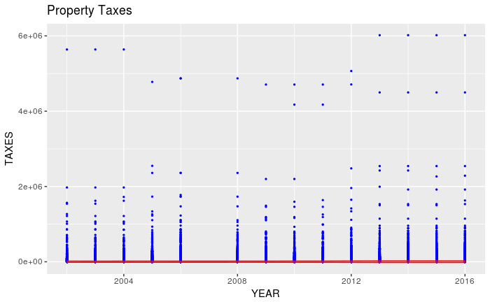

Now we upload the parcel shapefile and build a spatial object using the most recent parcel shapefile (2016) available. Due to computational intensity of building an adjacency matrix for a ~300,000 by ~300,000 matrix create a continuous SPDE mesh based on the centroids of the parcel polygons instead.

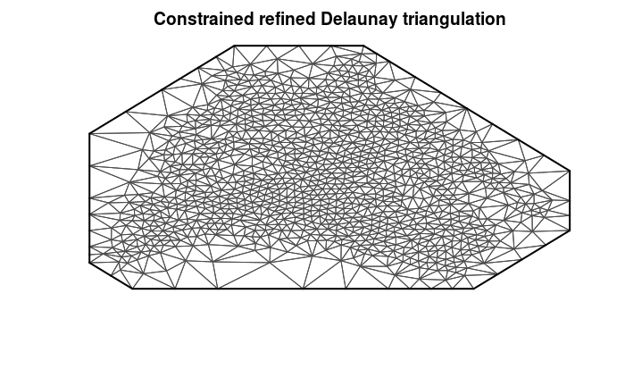

Now I setup an INLA run that will estimate the relationship between spatial location and change in property taxes.

```r
dat<-dfull
```

We would now like to see how the spatial effect is distributed across Davidson County. We do this by projecting the estimated effects onto a spatial grid.

```r
bounds<-extent(shp) #find the min and max extents of Davidson County for grid creation

stepsize<-1/111 #should give a roughly 1km by 1km pixel grid-->check this, something is off

nxy<-round(c(diff(range(bounds@xmax, bounds@xmin)), diff(range(bounds@ymin,bounds@ymax)))/stepsize) #number of pixels

projgrid<-inla.mesh.projector(mesh, xlim=range(bounds@xmax, bounds@xmin),ylim=range(bounds@ymin,bounds@ymax),dims=nxy) #associate inla mesh with grid

# xmean<-inla.mesh.project(projgrid, null$summary.random$s$mean) #associate the estimates with the grid
# xsd<-inla.mesh.project(projgrid, null$summary.random$s$sd)
#
# #combine the results with the locations in a dataframe
#  test<-as.vector(xmean)
#       test2<-as.vector(xsd)
#       t<-cbind(projgrid$lattice$loc, test,test2)
#       t<- as.data.frame(t)
#       colnames(t)<-c("x","y","mean","sd")
#
# #remove parts of the plot outside the county border
# library(lattice)
# library(sp)
# library(rgeos)
# library(maptools)
#
#       coordinates(t)<-cbind(t$x,t$y)
#       proj4string(t)<-proj4string(shp)
#       tclip<-t[shp,]
#       plot(tclip)
#       gridded(tclip)<-TRUE
#       plot(tclip)
#

#plot the spatial effect estimates
      plot(tclip[ ,"mean"], main="Mean Spatial Effect on Total Appraisal Values")
      plot(tclip[ ,"sd"], main="Standard Deviation in Spatial Effect of Total Appraisal Values")
```

[output not shown]

I then setup a model that will estimate the realtionship between Residential Property Sales and Parcel Appraisal Values with spatial effects accounted for.

```r
summary(sale2s)
```

```
Call:
c("inla(formula = sales.mod, family = \"gaussian\", data = inla.stack.data(stack.d2, ",  "    spde = spde), verbose = T, control.predictor = list(A = inla.stack.A(stack.d2), ",  "    compute = FALSE), control.fixed = list(prec.intercept = 0.1))" )

Time used:
 Pre-processing    Running inla Post-processing           Total
        12.1761      22179.2352          0.5113      22191.9225

Fixed effects:
            mean     sd 0.025quant 0.5quant 0.975quant   mode kld
intercept 1.9735 0.1703     1.6052   1.9833     2.2859 2.0007   0
SALEPRICE 0.0367 0.0005     0.0356   0.0367     0.0377 0.0367   0

Random effects:
Name      Model
 spatial.field   SPDE2 model

Model hyperparameters:
                                          mean     sd 0.025quant 0.5quant 0.975quant   mode
Precision for the Gaussian observations  3.845 0.0077      3.830    3.845      3.861  3.844
Theta1 for spatial.field                -4.715 0.0337     -4.783   -4.715     -4.650 -4.713
Theta2 for spatial.field                 3.671 0.1360      3.396    3.675      3.930  3.685

Expected number of effective parameters(std dev): 990.00(2.803)
Number of equivalent replicates : 556.79

Marginal log-Likelihood:  -420405.82
```

Now we are interested in seeing how this relationship changes between time periods pre and post 2010 (flood year). We first estimate a model for all time prior to 2010 (2003-2009).

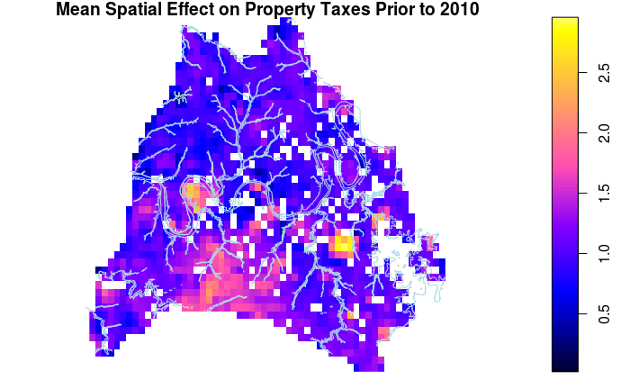

Now we estimate a model for all time post 2010 (2011-2016).

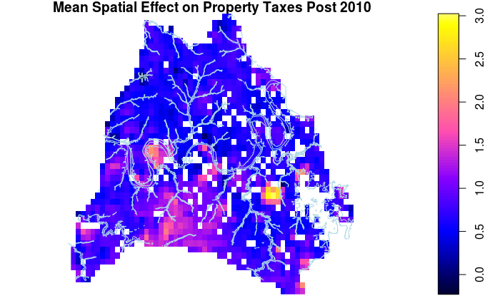

Now we would like to see the difference in the spatial effects

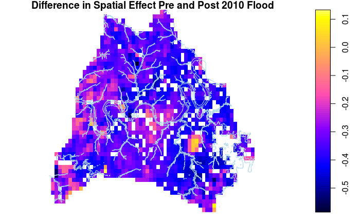